# Part II - Prosper Loan Data Exploration

## by Lekan Adenusi

## Investigation Overview

In my presentation I focus on how the loaned amount, prosper rating, credit scores, and the income range affect the Annual Percentage Rate or APR (the rate charged on the original loan annually) of the loan, as well as the exciting interactions observed between them. There are no major changes to the visualizations used during the exploratory phase.

## Dataset Overview

The dataset used for this project is the Prosper Loan Data provided by Udacity. It contains over 100,000 loans with 81 attributes. Only few of these features were considered, and in this presentation I narrow my focus to the useful ones.

## Distribution of APR and Loan Amounts

I begin by considering the distribution of the APR and the loan amounts using a histogram. Here we see the distribution of the APR is almost normal but not quite so; it also has most of its values between 0.1 and 0.4.

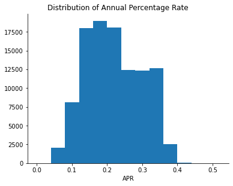

## Distribution of Selected Features

Let us consider the loan amounts first. We see that the spikes in the distribution reveal that most loans are usually procured in multiples of 1,000. Besides the occasional spikes, the distribution of the loan amounts is right-skewed with relatively only few amounts around 20k USD and above. Also, both credit scores have a similar distribution, suggesting that that both values are related by some constant.

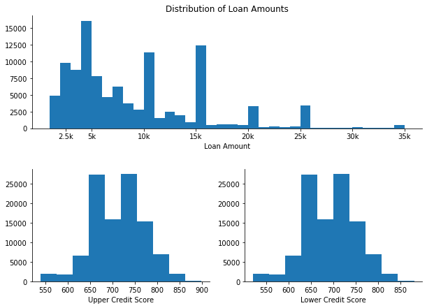

## Visualizing Correlations Between Variables

To start off with exploring the relationships between my features and the APR, let's see a correlation plot. There's a negative correlation between all three variables and the APR, although they are only moderate. This indicates that as these features become larger, the APR becomes smaller.

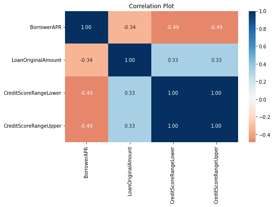

## Effect of Loan Amount on the APR

An interesting insight is revealed here. The boxplots show that high loan amounts, on general, incure relatively lower APR, and vice versa. Also, notice that the group 1-5K has the highest variance, while the group > 15K has the lowest variance. This shows that smaller loans have a more variable APR, compared to higher amounts of loans. In the second plot, the data was aggregated by its mean, and we see again how the line slopes down, supporting our observation from the boxplot.

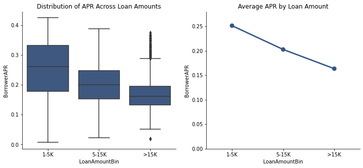

## Distribution of Borrower APR by Prosper Rating

There is a clear distinction in the distribution of the Borrower APR across the prosper ratings. Interestingly the median APR increases as the prosper rating becomes worse. I have also removed the outliers to keep the plot from being too busy. In the next slide we'll dig further into how the loan amount varies across the prosper ratings.

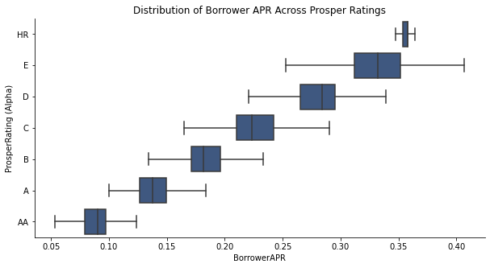

## Distribution of Loan Amounts Across Prosper Ratings

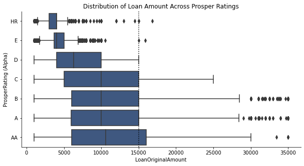

## What's the Proportion of Income Ranges Across Prosper Ratings?

The proportion of loanees earning high amounts increases as the Prosper score becomes better from left to right while the proportion of those earning lower, for example, between 1 and 25K USD decreases with increasing prosper rating, though this change is less pronounced compared to the former. To sum up, we'll look at the combined effect of loan amount and income range on the borrower APR.

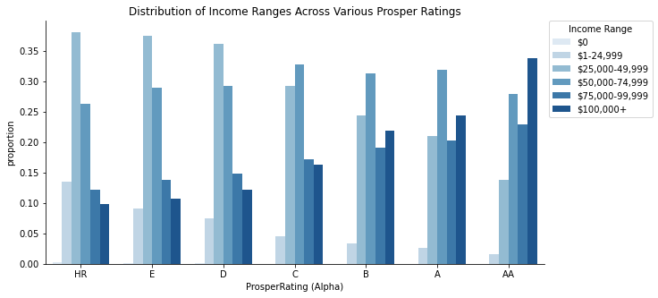

## Combined Effect of Income Range and Loan Amount on APR

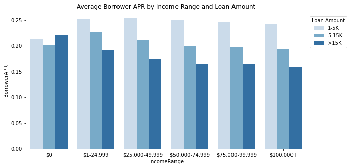